# Bank Loan Analysis Report

## Business Problem

A financial institution wants to analyze its lending portfolio to better understand loan performance, borrower behavior, and repayment trends.

The objective of this analysis is to evaluate key lending metrics, identify patterns in loan applications, assess regional and borrower-level trends, and distinguish between good and bad loans based on repayment status.

The analysis focuses on answering the following business questions:

- How many loan applications were received during the year?
- What is the total amount funded and received by the bank?
- What percentage of loans are classified as Good Loans and Bad Loans?
- Which states contribute the highest lending activity?
- How do loan terms impact funding and repayment performance?
- Does employment length influence borrowing behavior?
- What are the primary reasons borrowers seek loans?
- How does home ownership affect loan applications and funding?

The insights generated from this analysis can help stakeholders monitor portfolio performance, identify risk areas, and make data-driven lending decisions.

#### Import Libraries

```python
import pandas as pd
import numpy as np
import matplotlib.pyplot as plt
import seaborn as sns
import warnings
import plotly.express as px
```

```python
df=pd.read_excel("financial_loan.xlsx")
```

```python
df.head(10)
```

|  | id | address_state | application_type | emp_length | emp_title | grade | home_ownership | issue_date | last_credit_pull_date | last_payment_date | ... | sub_grade | term | verification_status | annual_income | dti | installment | int_rate | loan_amount | total_acc | total_payment |
| --- | --- | --- | --- | --- | --- | --- | --- | --- | --- | --- | --- | --- | --- | --- | --- | --- | --- | --- | --- | --- | --- |
| 0 | 1077430 | GA | INDIVIDUAL | < 1 year | Ryder | C | RENT | 2021-02-11 | 2021-09-13 | 2021-04-13 | ... | C4 | 60 months | Source Verified | 30000.0 | 0.0100 | 59.83 | 0.1527 | 2500 | 4 | 1009 |
| 1 | 1072053 | CA | INDIVIDUAL | 9 years | MKC Accounting | E | RENT | 2021-01-01 | 2021-12-14 | 2021-01-15 | ... | E1 | 36 months | Source Verified | 48000.0 | 0.0535 | 109.43 | 0.1864 | 3000 | 4 | 3939 |
| 2 | 1069243 | CA | INDIVIDUAL | 4 years | Chemat Technology Inc | C | RENT | 2021-01-05 | 2021-12-12 | 2021-01-09 | ... | C5 | 36 months | Not Verified | 50000.0 | 0.2088 | 421.65 | 0.1596 | 12000 | 11 | 3522 |
| 3 | 1041756 | TX | INDIVIDUAL | < 1 year | barnes distribution | B | MORTGAGE | 2021-02-25 | 2021-12-12 | 2021-03-12 | ... | B2 | 60 months | Source Verified | 42000.0 | 0.0540 | 97.06 | 0.1065 | 4500 | 9 | 4911 |
| 4 | 1068350 | IL | INDIVIDUAL | 10+ years | J&J Steel Inc | A | MORTGAGE | 2021-01-01 | 2021-12-14 | 2021-01-15 | ... | A1 | 36 months | Verified | 83000.0 | 0.0231 | 106.53 | 0.0603 | 3500 | 28 | 3835 |
| 5 | 1062608 | CA | INDIVIDUAL | 3 years | Studio 94 Corp | C | RENT | 2021-07-17 | 2021-03-16 | 2021-08-12 | ... | C3 | 36 months | Not Verified | 28000.0 | 0.1260 | 275.96 | 0.1465 | 8000 | 11 | 8637 |
| 6 | 1067441 | TX | INDIVIDUAL | 10+ years | American Airlines | C | MORTGAGE | 2021-11-19 | 2021-06-14 | 2021-12-13 | ... | C2 | 36 months | Verified | 94800.0 | 0.2453 | 205.86 | 0.1427 | 6000 | 30 | 7218 |
| 7 | 1066424 | PA | INDIVIDUAL | 10+ years | SCI Mahanoy | A | OWN | 2021-06-11 | 2021-07-14 | 2021-07-14 | ... | A4 | 36 months | Source Verified | 59000.0 | 0.0665 | 172.10 | 0.0790 | 5500 | 23 | 6172 |
| 8 | 1065254 | FL | INDIVIDUAL | 10+ years | Tech Data Corp | A | MORTGAGE | 2021-09-02 | 2021-06-15 | 2021-10-12 | ... | A5 | 36 months | Verified | 116400.0 | 0.0394 | 762.08 | 0.0890 | 24000 | 31 | 8650 |
| 9 | 1064589 | MI | INDIVIDUAL | 10+ years | teltow contracting | B | MORTGAGE | 2021-02-09 | 2021-03-16 | 2021-03-16 | ... | B5 | 60 months | Not Verified | 36000.0 | 0.1773 | 93.21 | 0.1269 | 4125 | 21 | 5551 |

10 rows × 24 columns

### Metadata

```python
print("No.of rows:",df.shape[0])
```

```
No.of rows: 38576
```

```python
print("No.of columns:",df.shape[1])
```

```
No.of columns: 24
```

```python
df.info()
```

```
<class 'pandas.core.frame.DataFrame'>
RangeIndex: 38576 entries, 0 to 38575
Data columns (total 24 columns):
 #   Column                 Non-Null Count  Dtype
---  ------                 --------------  -----
 0   id                     38576 non-null  int64
 1   address_state          38576 non-null  object
 2   application_type       38576 non-null  object
 3   emp_length             38576 non-null  object
 4   emp_title              37138 non-null  object
 5   grade                  38576 non-null  object
 6   home_ownership         38576 non-null  object
 7   issue_date             38576 non-null  datetime64[ns]
 8   last_credit_pull_date  38576 non-null  datetime64[ns]
 9   last_payment_date      38576 non-null  datetime64[ns]
```

[output cut: 16 more lines]

### data types

```python
df.dtypes
```

```
id                                int64
address_state                    object
application_type                 object
emp_length                       object
emp_title                        object
grade                            object
home_ownership                   object
issue_date               datetime64[ns]
last_credit_pull_date    datetime64[ns]
last_payment_date        datetime64[ns]
loan_status                      object
next_payment_date        datetime64[ns]
member_id                         int64
purpose                          object
sub_grade                        object
term                             object
verification_status              object
annual_income                   float64
dti                             float64
installment                     float64
int_rate                        float64
loan_amount                       int64
total_acc                         int64
total_payment                     int64
dtype: object
```

```python
df.describe()
```

|  | id | issue_date | last_credit_pull_date | last_payment_date | next_payment_date | member_id | annual_income | dti | installment | int_rate | loan_amount | total_acc | total_payment |
| --- | --- | --- | --- | --- | --- | --- | --- | --- | --- | --- | --- | --- | --- |
| count | 3.857600e+04 | 38576 | 38576 | 38576 | 38576 | 3.857600e+04 | 3.857600e+04 | 38576.000000 | 38576.000000 | 38576.000000 | 38576.000000 | 38576.000000 | 38576.000000 |
| mean | 6.810371e+05 | 2021-07-16 02:31:35.562007040 | 2021-06-08 13:36:34.193280512 | 2021-06-26 09:52:08.909166080 | 2021-07-26 20:42:20.605557760 | 8.476515e+05 | 6.964454e+04 | 0.133274 | 326.862965 | 0.120488 | 11296.066855 | 22.132544 | 12263.348533 |
| min | 5.473400e+04 | 2021-01-01 00:00:00 | 2021-01-08 00:00:00 | 2021-01-08 00:00:00 | 2021-02-08 00:00:00 | 7.069900e+04 | 4.000000e+03 | 0.000000 | 15.690000 | 0.054200 | 500.000000 | 2.000000 | 34.000000 |
| 25% | 5.135170e+05 | 2021-04-11 00:00:00 | 2021-04-15 00:00:00 | 2021-03-16 00:00:00 | 2021-04-16 00:00:00 | 6.629788e+05 | 4.150000e+04 | 0.082100 | 168.450000 | 0.093200 | 5500.000000 | 14.000000 | 5633.000000 |
| 50% | 6.627280e+05 | 2021-07-11 00:00:00 | 2021-05-16 00:00:00 | 2021-06-14 00:00:00 | 2021-07-14 00:00:00 | 8.473565e+05 | 6.000000e+04 | 0.134200 | 283.045000 | 0.118600 | 10000.000000 | 20.000000 | 10042.000000 |
| 75% | 8.365060e+05 | 2021-10-11 00:00:00 | 2021-08-13 00:00:00 | 2021-09-15 00:00:00 | 2021-10-15 00:00:00 | 1.045652e+06 | 8.320050e+04 | 0.185900 | 434.442500 | 0.145900 | 15000.000000 | 29.000000 | 16658.000000 |
| max | 1.077501e+06 | 2021-12-12 00:00:00 | 2022-01-20 00:00:00 | 2021-12-15 00:00:00 | 2022-01-15 00:00:00 | 1.314167e+06 | 6.000000e+06 | 0.299900 | 1305.190000 | 0.245900 | 35000.000000 | 90.000000 | 58564.000000 |
| std | 2.113246e+05 | NaN | NaN | NaN | NaN | 2.668105e+05 | 6.429368e+04 | 0.066662 | 209.092000 | 0.037164 | 7460.746022 | 11.392282 | 9051.104777 |

## KPI 1: Total Loan Applications

This KPI measures the total number of loan applications received during the analysis period. It helps evaluate overall lending demand and provides visibility into Month-to-Date (MTD) application trends.

```python
# Count total loan records in the dataset
Tot_loan_Applications=df["id"].count()
print("Total Loan Applications:",Tot_loan_Applications)
```

```
Total Loan Applications: 38576
```

#### MTD Total Loan Applications

```python
# Filter records for the latest month and count applications

Latest_issue_date= df['issue_date'].max()

# Extract year and month from the latest issue dat
Latest_year=Latest_issue_date.year
Latest_month=Latest_issue_date.month

# Count loan applications submitted during the latest month

mtd_data=df[(df['issue_date'].dt.year==Latest_year)&(df['issue_date'].dt.month==Latest_month)]

# Count loan applications submitted during the latest month

mtd_total_applications=mtd_data['id'].count()

print(f"Total MTD Applications (for {Latest_issue_date.strftime('%B %Y')}): {mtd_total_applications}")
```

```
Total MTD Applications (for December 2021): 4314
```

## KPI 2: Total Funded Amount

This KPI represents the total amount of money disbursed as loans. Monitoring funded amounts helps assess lending activity and capital deployment.

```python
# Sum all loan amounts to calculate total funds issued

total_funded_amount = df['loan_amount'].sum()
total_funded_amount_millions = total_funded_amount/1000000

print(f"Total funded amount:${total_funded_amount_millions:.2f}M")
```

```
Total funded amount:$435.76M
```

#### MTD Total Funded Amount

```python
# Get the most recent issue date available in the dataset

Latest_issue_date= df['issue_date'].max()

# Extract year and month from the latest issue date

Latest_year=Latest_issue_date.year
Latest_month=Latest_issue_date.month

# Filter records belonging to the latest month

mtd_data=df[(df['issue_date'].dt.year==Latest_year)&(df['issue_date'].dt.month==Latest_month)]

# Sum funded amount for loans issued during the latest month

mtd_total_funded_amount = mtd_data['loan_amount'].sum()
mtd_total_funded_amount_millions = mtd_total_funded_amount/1000000
print(f'mtd total funded amount: ${mtd_total_funded_amount_millions:.2f}M')
```

```
mtd total funded amount: $53.98M
```

## KPI 3: Total Amount Received

This KPI tracks the total repayments received from borrowers. It helps evaluate cash inflows and overall repayment performance.

```python
# Sum all borrower payments received
total_Received_amount = df['total_payment'].sum()
total_Received_amount_millions = total_Received_amount/1000000

print(f"total_Received_amountt:${total_Received_amount_millions:.2f}M")
```

```
total_Received_amountt:$473.07M
```

#### MTD Total Received Amount

```python
Latest_issue_date= df['issue_date'].max()
Latest_year=Latest_issue_date.year
Latest_month=Latest_issue_date.month

# Filter records belonging to the latest month

mtd_data=df[(df['issue_date'].dt.year==Latest_year)&(df['issue_date'].dt.month==Latest_month)]

# Sum payments received for loans in the latest month

mtd_total_Received_amount = mtd_data['total_payment'].sum()
mtd_total_Received_amount_millions = mtd_total_Received_amount/1000000

# Convert amount into millions for reporting

print(f'mtd total Received amount: ${mtd_total_Received_amount_millions:.2f}M')
```

```
mtd total Received amount: $58.07M
```

## KPI 4: Average Interest Rate

This KPI calculates the average interest rate across all issued loans and provides insights into the overall pricing of the lending portfolio.

```python
# Calculate average interest rate across all loans

Avg_interest_rate = df['int_rate'].mean()*100
print(f'Average interest rate is :{Avg_interest_rate:.2f}%')
```

```
Average interest rate is :12.05%
```

## KPI 5: Average Debt-to-Income Ratio (DTI)

This KPI measures the average borrower debt burden relative to income and helps assess borrower financial health.

```python
# Calculate average debt-to-income ratio of borrowers

avg_dti = df['dti'].mean()*100
print(f'avg_dti_Income_ratio :{avg_dti:.2f}%')
```

```
avg_dti_Income_ratio :13.33%
```

## Good Loan Analysis

Good Loans are defined as loans with a status of 'Fully Paid' or 'Current'.

The objective of this analysis is to determine:

- Good Loan Application Percentage
- Total Good Loan Applications
- Good Loan Funded Amount
- Good Loan Total Received Amount

These metrics help evaluate the healthy portion of the lending portfolio.

```python
# Filter loans with status Fully Paid or Current

good_loans=df[df['loan_status'].isin(['Fully Paid','Current'])]

total_applications=df['id'].count()

# Count total good loan applications

Good_loan_applications=good_loans['id'].count()

# Sum funded amount for good loans

Good_loan_funded_amount=good_loans['loan_amount'].sum()

# Sum payments received from good loans

Good_loan_Received_amount=good_loans['total_payment'].sum()

Good_loan_funded_amount_millions = Good_loan_funded_amount/1000000
Good_loan_Received_amount = Good_loan_Received_amount/1000000

# Calculate good loan percentage based on application count

Good_loan_percentage=(Good_loan_applications/total_applications)*100

print(f'Good_loan_applications : {Good_loan_applications}')
print(f'Good_loan_applications percentage : {Good_loan_percentage:.2f}%')
print(f'Good_loan_funded_amount : ${Good_loan_funded_amount_millions:.2f}M')
print(f'Good_loan_Received_amount : ${Good_loan_Received_amount:.2f}M')
```

```
Good_loan_applications : 33243
Good_loan_applications percentage : 86.18%
Good_loan_funded_amount : $370.22M
Good_loan_Received_amount : $435.79M
```

## Bad Loan Analysis

Bad Loans are defined as loans with a status of 'Charged Off'.

The objective of this analysis is to determine:

- Bad Loan Application Percentage
- Total Bad Loan Applications
- Bad Loan Funded Amount
- Bad Loan Total Received Amount

These metrics help assess portfolio risk and potential financial losses.

```python
# Filter charged-off loans

bad_loans=df[df['loan_status'].isin(['Charged Off'])]

# Count total bad loan applications

total_applications=df['id'].count()
bad_loan_applications=bad_loans['id'].count()
bad_loan_funded_amount=bad_loans['loan_amount'].sum()
bad_loan_Received_amount=bad_loans['total_payment'].sum()

bad_loan_funded_amount_millions = bad_loan_funded_amount/1000000
bad_loan_Received_amount = bad_loan_Received_amount/1000000

# Calculate bad loan percentage based on application count

bad_loan_percentage=(bad_loan_applications/total_applications)*100

print(f'bad_loan_applications : {bad_loan_applications}')
print(f'bad_loan_applications percentage : {bad_loan_percentage:.2f}%')
print(f'bad_loan_funded_amount : ${bad_loan_funded_amount_millions:.2f}M')
print(f'bad_loan_Received_amount : ${bad_loan_Received_amount:.2f}M')
```

```
bad_loan_applications : 5333
bad_loan_applications percentage : 13.82%
bad_loan_funded_amount : $65.53M
bad_loan_Received_amount : $37.28M
```

## Monthly Lending Trends

### Monthly trends by Issue Date for Total Funded Amount

This analysis examines monthly loan applications, funded amounts, and received payments to identify growth patterns, seasonality, and overall lending performance throughout the year.

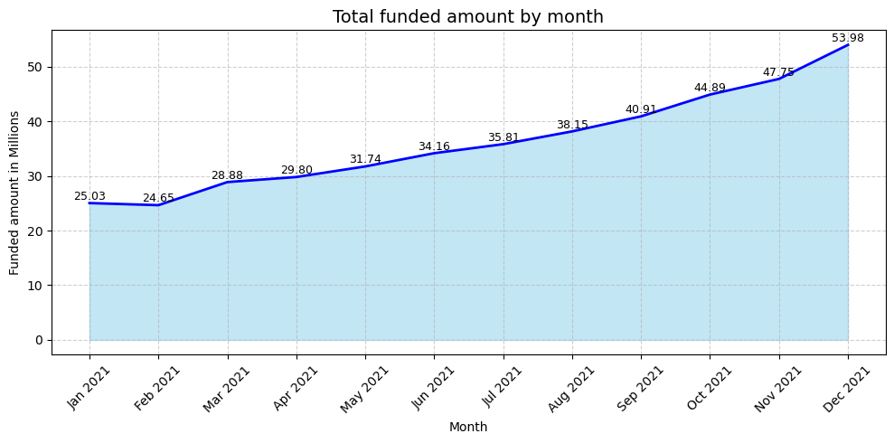

```python
# Aggregate funded amount by issue month

monthly_funded=(
    df.sort_values('issue_date')
        .assign(month_name=lambda x:x['issue_date'].dt.strftime('%b %Y'))
        .groupby('month_name',sort=False)['loan_amount']
        .sum()
        .div(1000000)
        .reset_index(name='loan_amount_millions'))

plt.figure(figsize=(10,5))
plt.fill_between(monthly_funded['month_name'],monthly_funded['loan_amount_millions'],color='skyblue',alpha=0.5)
plt.plot(monthly_funded['month_name'],monthly_funded['loan_amount_millions'],color='blue',linewidth=2)

for i,row in monthly_funded.iterrows():
    plt.text(i,row['loan_amount_millions']+0.1,f"{row['loan_amount_millions']:.2f}",
        ha='center',va='bottom',fontsize=9,rotation=0,color='black')

plt.title('Total funded amount by month',fontsize=14)
plt.xlabel('Month')
plt.ylabel('Funded amount in Millions')
plt.xticks(ticks=range(len(monthly_funded)),labels=monthly_funded['month_name'],rotation=45)
plt.grid(True,linestyle='--',alpha=0.6)
plt.tight_layout()
plt.show()
```

### Monthly trends by Issue Date for Total Amount Received

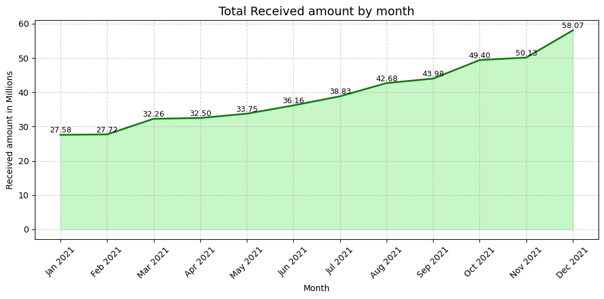

```python
# Aggregate received amount by issue month


monthly_Received=(
    df.sort_values('issue_date')
        .assign(month_name=lambda x:x['issue_date'].dt.strftime('%b %Y'))
        .groupby('month_name',sort=False)['total_payment']
        .sum()
        .div(1000000)
        .reset_index(name='Received_amount_millions'))

plt.figure(figsize=(10,5))
plt.fill_between(monthly_Received['month_name'],monthly_Received['Received_amount_millions'],color='lightgreen',alpha=0.5)
plt.plot(monthly_Received['month_name'],monthly_Received['Received_amount_millions'],color='Green',linewidth=2)

for i,row in monthly_Received.iterrows():
    plt.text(i,row['Received_amount_millions']+0.1,f"{row['Received_amount_millions']:.2f}",
        ha='center',va='bottom',fontsize=9,rotation=0,color='black')

plt.title('Total Received amount by month',fontsize=14)
plt.xlabel('Month')
plt.ylabel('Received amount in Millions')
plt.xticks(ticks=range(len(monthly_Received)),labels=monthly_Received['month_name'],rotation=45)
plt.grid(True,linestyle='--',alpha=0.6)
plt.tight_layout()
plt.show()
```

### Monthly trends by Issue Date for Total Loan Applications

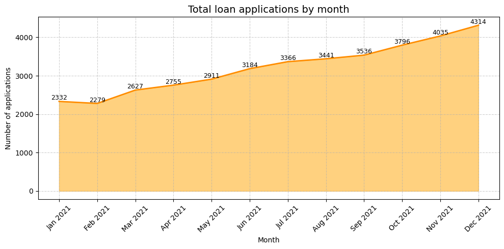

```python
# Count applications for each issue month

monthly_applications=(
    df.sort_values('issue_date')
        .assign(month_name=lambda x:x['issue_date'].dt.strftime('%b %Y'))
        .groupby('month_name',sort=False)['id']
        .count()
        .reset_index(name='Loan_applications_count'))

plt.figure(figsize=(10,5))
plt.fill_between(monthly_applications['month_name'],monthly_applications['Loan_applications_count'],color='orange',alpha=0.5)
plt.plot(monthly_applications['month_name'],monthly_applications['Loan_applications_count'],color='darkorange',linewidth=2)

for i,row in monthly_applications.iterrows():
    plt.text(i,row['Loan_applications_count']+0.5,f"{row['Loan_applications_count']}",
        ha='center',va='bottom',fontsize=9,rotation=0,color='black')

plt.title('Total loan applications by month',fontsize=14)
plt.xlabel('Month')
plt.ylabel('Number of applications')
plt.xticks(ticks=range(len(monthly_applications)),labels=monthly_applications['month_name'],rotation=45)
plt.grid(True,linestyle='--',alpha=0.6)
plt.tight_layout()
plt.show()
```

## Regional Analysis by State

### Regional Analysis For Total Funded Amount

This analysis evaluates lending activity across different states to identify regions with the highest loan demand, funding volume, and repayment performance.

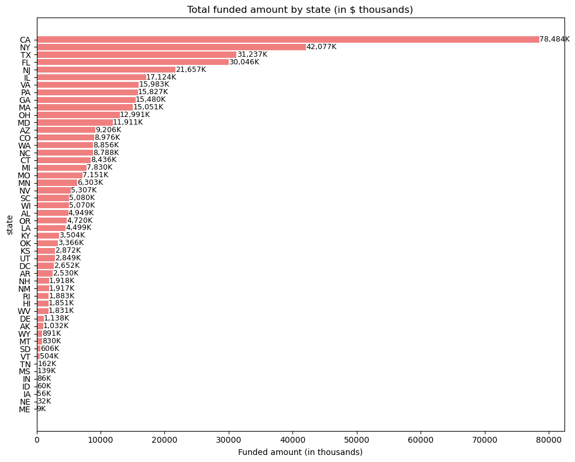

```python
# Calculate total funded amount for each state

state_funding=df.groupby('address_state')['loan_amount'].sum().sort_values(ascending=True)
state_funding_thousand=state_funding/1000
plt.figure(figsize=(10,8))
bars=plt.barh(state_funding_thousand.index,state_funding_thousand.values,color='lightcoral')

for bar in bars:
    width=bar.get_width()
    plt.text(width+10,bar.get_y()+bar.get_height()/2,
    f'{width:,.0f}K',va='center',fontsize=9)

plt.title('Total funded amount by state (in $ thousands)')
plt.xlabel('Funded amount (in thousands)')
plt.ylabel('state')
plt.tight_layout()
plt.show()
```

### Regional Analysis For Total Received Amount

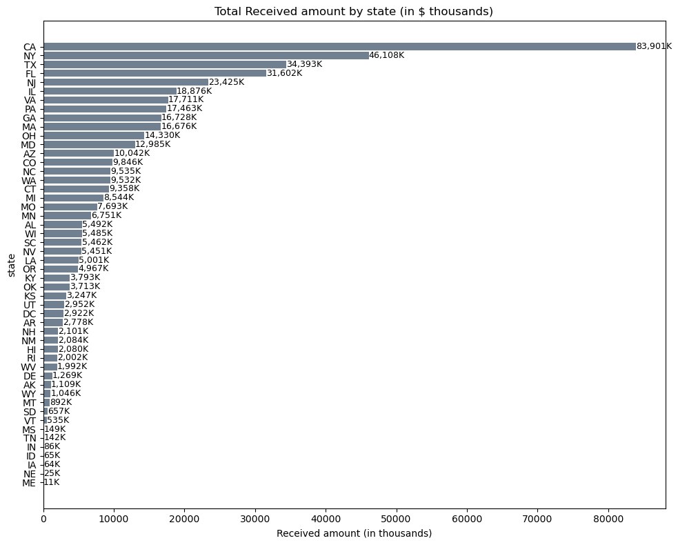

```python
# Calculate total received amount for each state

state_Received=df.groupby('address_state')['total_payment'].sum().sort_values(ascending=True)
state_Received_thousand=state_Received/1000
plt.figure(figsize=(10,8))
bars=plt.barh(state_Received_thousand.index,state_Received_thousand.values,color='slategray')

for bar in bars:
    width=bar.get_width()
    plt.text(width+10,bar.get_y()+bar.get_height()/2,
    f'{width:,.0f}K',va='center',fontsize=9)

plt.title('Total Received amount by state (in $ thousands)')
plt.xlabel('Received amount (in thousands)')
plt.ylabel('state')
plt.tight_layout()
plt.show()
```

### Regional Analysis For Total Loan Applications

[figure not shown]

```python
# Count loan applications by state

state_wise_loan_applications=df.groupby('address_state')['id'].count().sort_values(ascending=True)
plt.figure(figsize=(10,8))
bars=plt.barh(state_wise_loan_applications.index,state_wise_loan_applications.values,color='gold')

for bar in bars:
    width=bar.get_width()
    plt.text(width+10,bar.get_y()+bar.get_height()/2,
    f'{width:,.0f}K',va='center',fontsize=9)

plt.title('Total applications by state wise')
plt.xlabel('total applications count')
plt.ylabel('state')
plt.tight_layout()
plt.show()
```

## Loan Term Analysis

This analysis examines how loan funding and repayments are distributed across different loan terms, helping understand borrower preferences and portfolio composition.

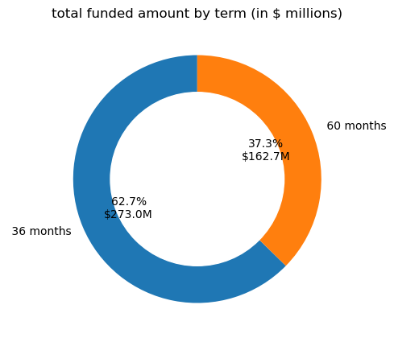

```python
# Summarize funded amount by loan term

term_funding_millions=df.groupby('term')['loan_amount'].sum()/1000000

plt.figure(figsize=(5,5))
plt.pie(
    term_funding_millions,
    labels=term_funding_millions.index,
    autopct=lambda p:f'{p:.1f}%\n${p*sum(term_funding_millions)/100:.1f}M',
    startangle=90,
wedgeprops={'width':0.4}
)

plt.gca().add_artist(plt.Circle((0,0),0.70,color='white'))
plt.title("total funded amount by term (in $ millions)")
plt.show()
```

### Long Term by total Received amount

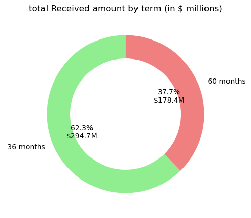

```python
# Summarize received amount by loan term

term_Received_millions=df.groupby('term')['total_payment'].sum()/1000000

plt.figure(figsize=(5,5))
plt.pie(
    term_Received_millions,
    labels=term_Received_millions.index,
    autopct=lambda p:f'{p:.1f}%\n${p*sum(term_Received_millions)/100:.1f}M',
    colors=['lightgreen','lightcoral'],
    startangle=90,
wedgeprops={'width':0.4}
)

plt.gca().add_artist(plt.Circle((0,0),0.70,color='white'))
plt.title("total Received amount by term (in $ millions)")
plt.show()
```

## Employment Length Analysis

### Employment Length For Total Funded Amount

This analysis evaluates the relationship between borrower employment history and lending metrics to understand how employment stability influences borrowing behavior.

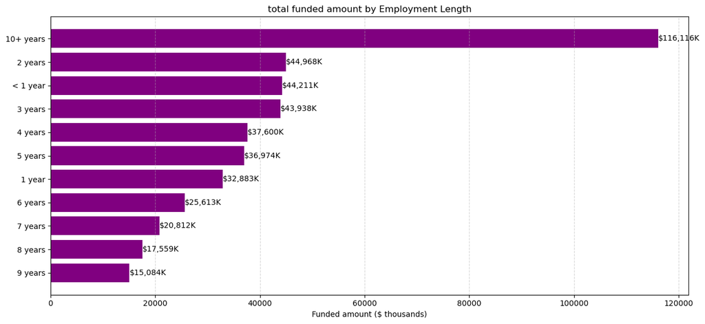

```python
# Aggregate funded amount by employment length

emp_funding=df.groupby('emp_length')['loan_amount'].sum().sort_values()/1000

plt.figure(figsize=(13,6))
bars=plt.barh(emp_funding.index,emp_funding.values,color='purple')

for bar in bars:
    width=bar.get_width()
    plt.text(width+7,bar.get_y()+bar.get_height()/2,
    f'${width:,.0f}K',va='center',fontsize=10)

plt.xlabel("Funded amount ($ thousands)")
plt.title("total funded amount by Employment Length")
plt.grid(axis='x',linestyle='--',alpha=0.5)
plt.tight_layout()
plt.show()
```

### Employment Length For Total Received Amount

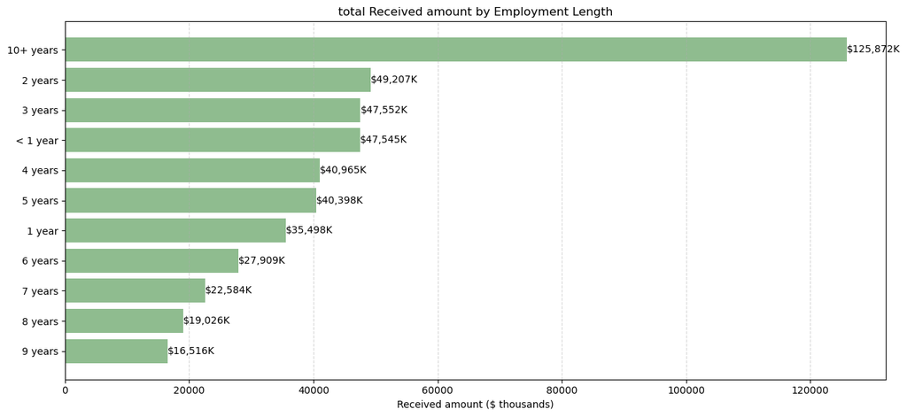

```python
# Aggregate received amount by employment length

emp_Receiving=df.groupby('emp_length')['total_payment'].sum().sort_values()/1000

plt.figure(figsize=(13,6))
bars=plt.barh(emp_Receiving.index,emp_Receiving.values,color='darkseagreen')

for bar in bars:
    width=bar.get_width()
    plt.text(width+7,bar.get_y()+bar.get_height()/2,
    f'${width:,.0f}K',va='center',fontsize=10)

plt.xlabel("Received amount ($ thousands)")
plt.title("total Received amount by Employment Length")
plt.grid(axis='x',linestyle='--',alpha=0.5)
plt.tight_layout()
plt.show()
```

## Loan Purpose Analysis

### Loan purpose by total funded amount

This analysis investigates the primary reasons borrowers seek financing and identifies which loan purposes contribute the most to funding and repayments.

[figure not shown]

```python
# Aggregate funded amount by loan purpose

purpose_funding=df.groupby('purpose')['loan_amount'].sum().sort_values()/1000000

plt.figure(figsize=(13,6))
bars=plt.barh(purpose_funding.index,purpose_funding.values,color='skyblue')

for bar in bars:
    width=bar.get_width()
    plt.text(width+1,bar.get_y()+bar.get_height()/2,
    f'${width:,.2f}M',va='center',fontsize=10)

plt.title("total funded amount by Employment Length",fontsize=14)
plt.xlabel("Funded amount in ($ Millions)")
plt.ylabel('Loan purpose')
plt.grid(axis='x',linestyle='--',alpha=0.5)
plt.tight_layout()
plt.show()
```

[figure not shown]

```python
# Aggregate received amount by loan purpose

purpose_Receiving=df.groupby('purpose')['total_payment'].sum().sort_values()/1000000

plt.figure(figsize=(13,6))
bars=plt.barh(purpose_Receiving.index,purpose_Receiving.values,color='deeppink')

for bar in bars:
    width=bar.get_width()
    plt.text(width+1,bar.get_y()+bar.get_height()/2,
    f'${width:,.2f}M',va='center',fontsize=10)

plt.title("total Received amount by Employment Length",fontsize=14)
plt.xlabel("Received amount in ($ Millions)")
plt.ylabel('Loan purpose')
plt.grid(axis='x',linestyle='--',alpha=0.5)
plt.tight_layout()
plt.show()
```

## Home Ownership Analysis

### Home Ownership by total funded amount

This analysis explores how borrower home ownership status impacts loan applications, funding amounts, and repayment behavior.

```python
# Aggregate funded amount by home ownership category

home_funding = (
    df.groupby('home_ownership')['loan_amount']
      .sum()
      .div(1000000)
      .reset_index(name='funded_amount_millions'))
fig=px.treemap(
    home_funding,
    path=['home_ownership'],
    values='funded_amount_millions',
    color='funded_amount_millions',
    color_continuous_scale='Blues',
    title='Total funded amount by ownership($ Millions)'
)
fig.show()
```

[interactive chart not shown]

### Home Ownership by total Received amount

```python
# Aggregate received amount by home ownership category

home_Receiving = (
    df.groupby('home_ownership')['total_payment']
      .sum()
      .div(1000000)
      .reset_index(name='Received_amount_millions'))
fig=px.treemap(
    home_Receiving,
    path=['home_ownership'],
    values='Received_amount_millions',
    color='Received_amount_millions',
    color_continuous_scale='Greens',
    title='Total Received amount by ownership($ Millions)'
)
fig.show()
```

[interactive chart not shown]

```python
print("=" * 45)
print("BANK LOAN ANALYSIS SUMMARY")
print("=" * 45)
print("Total Applications    : 38,576")
print("Good Loans            : 86.18%")
print("Bad Loans             : 13.82%")
print("Total Funded Amount   : $435.76M")
print("Total Received Amount : $473.07M")
print("Average Interest Rate : 12.05%")
print("Average DTI Ratio     : 13.33%")
print("Peak Month            : Dec 2021 (4,314 apps)")
print("Top State             : California ($78.48M)")
print("Top Loan Purpose      : Debt Consolidation ($232.46M)")
print("=" * 45)
```

```
=============================================
BANK LOAN ANALYSIS SUMMARY
=============================================
Total Applications    : 38,576
Good Loans            : 86.18%
Bad Loans             : 13.82%
Total Funded Amount   : $435.76M
Total Received Amount : $473.07M
Average Interest Rate : 12.05%
Average DTI Ratio     : 13.33%
Peak Month            : Dec 2021 (4,314 apps)
Top State             : California ($78.48M)
Top Loan Purpose      : Debt Consolidation ($232.46M)
=============================================
```